# Using waterNETN R pkg.

Plot temperature (in F) for Upper Hadlock for years 2013 - 2023 corrected by elevation with thermocline plotted as black lines, with gridlines on y.

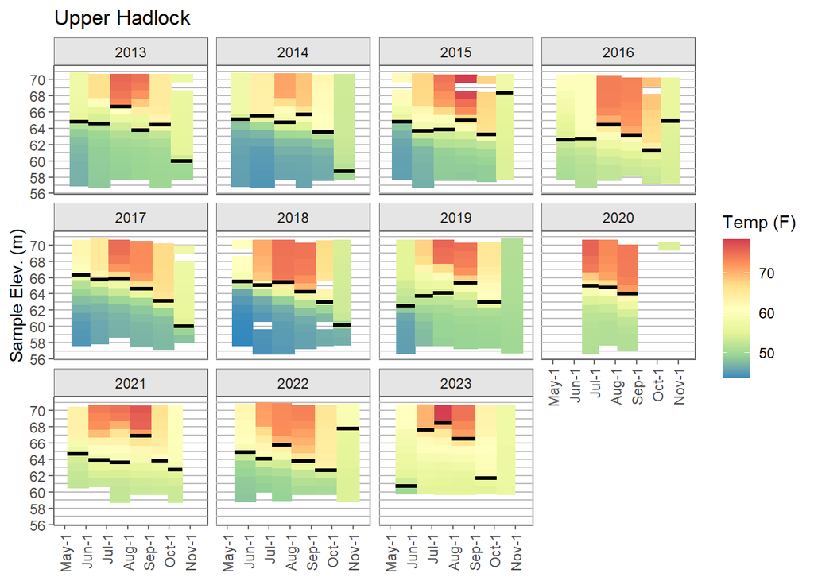

```r
plotLakeProfile(site = "ACUHAD", parameter = "Temp_F", depth_type = 'elev',
                years = 2013:2023, gridlines = "grid_y")
```

Plot temp (in C) using raw sample depth (default) for all LNETN lakes sampled in 2023.

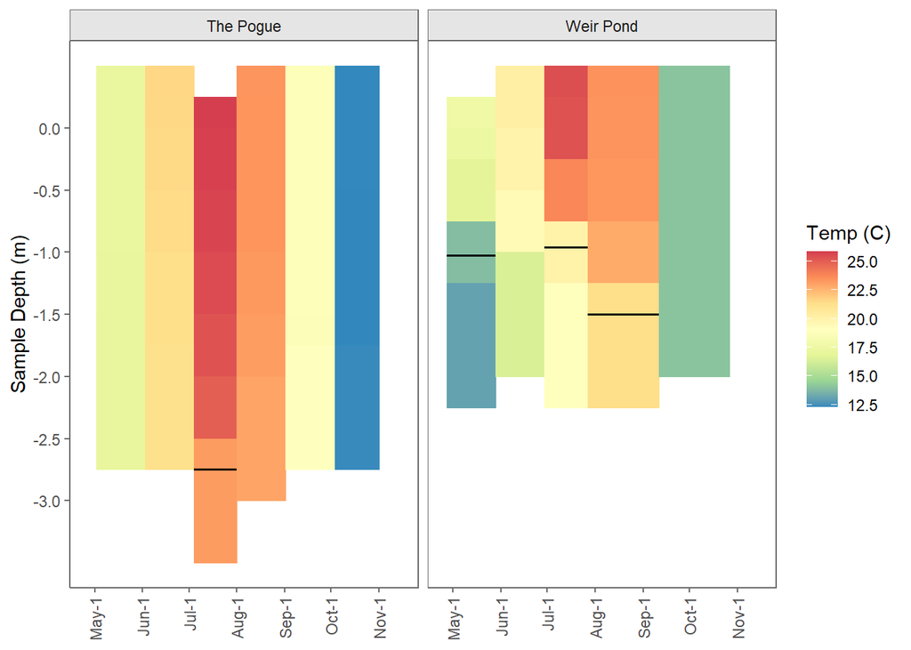

```r
plotLakeProfile(park = "LNETN", parameter = "Temp_C", years = 2023, palette = "Spectral")
```

Plot temperature for Eagle Lake for years 2006 - 2023 with raw sample depth. Note that we can go back to 2006 because we’re using raw sample depth instead of elevation.

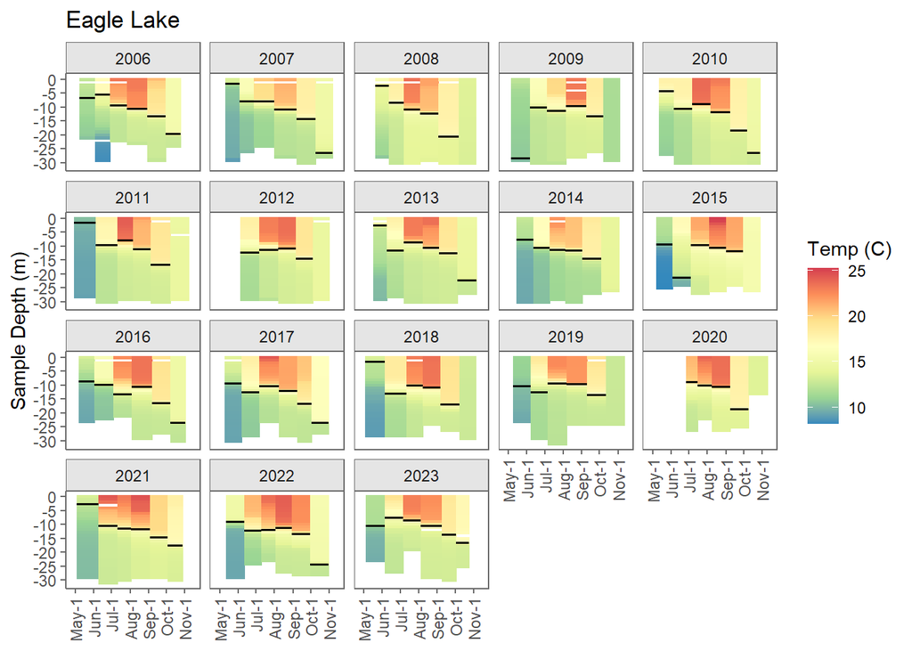

```r
plotLakeProfile(site = "ACEAGL", parameter = "Temp_C", depth_type = 'raw',
                years = 2006:2023)
```

Same plot as above, but with no plot title or thermocline.

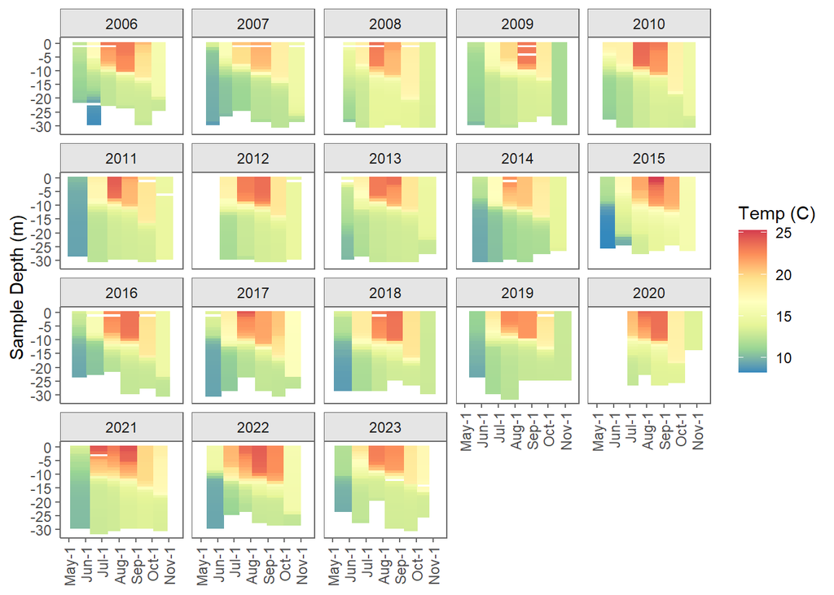

```r
plotLakeProfile(site = "ACEAGL", parameter = "Temp_C", depth_type = 'raw',
                years = 2006:2023, plot_title = FALSE, plot_thermocline = F)
```

Plot temperature for all ACAD lakes sampled in 2023 and raw sample depth.

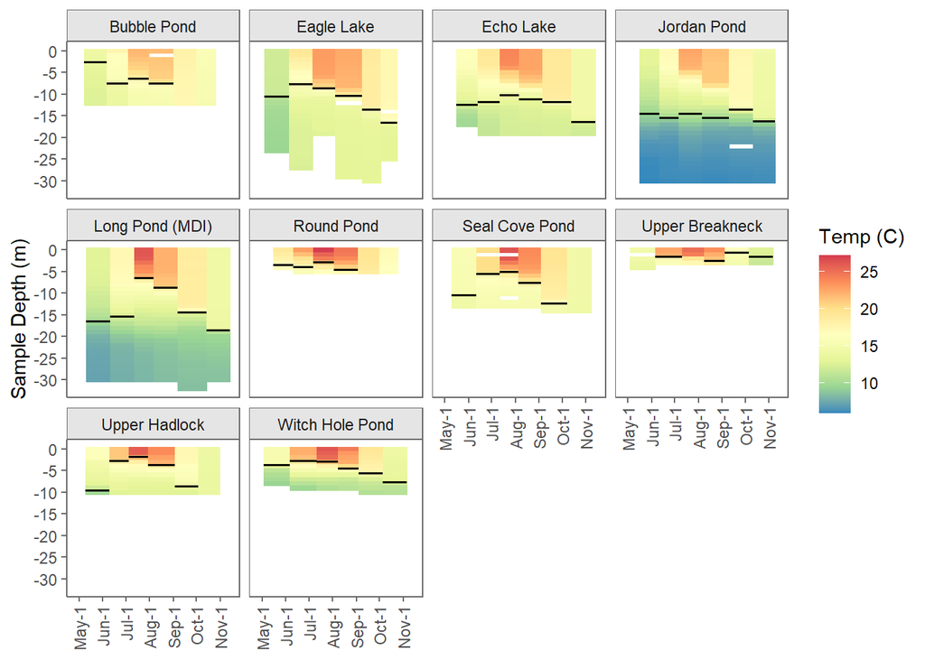

```r
lakes23 <- c("ACBUBL", "ACEAGL", "ACECHO", "ACJORD", "ACLONG", "ACROUN",
             "ACSEAL", "ACUBRK", "ACUHAD", "ACWHOL")
plotLakeProfile(park = "ACAD", site = lakes23, parameter = "Temp_C",
                depth_type = 'raw', years = 2023)
```

Plot DO all ACAD lakes sampled in 2023 and raw sample depth, using reversed RdYlBu palette. Temperature thermocline is also included as black lines.

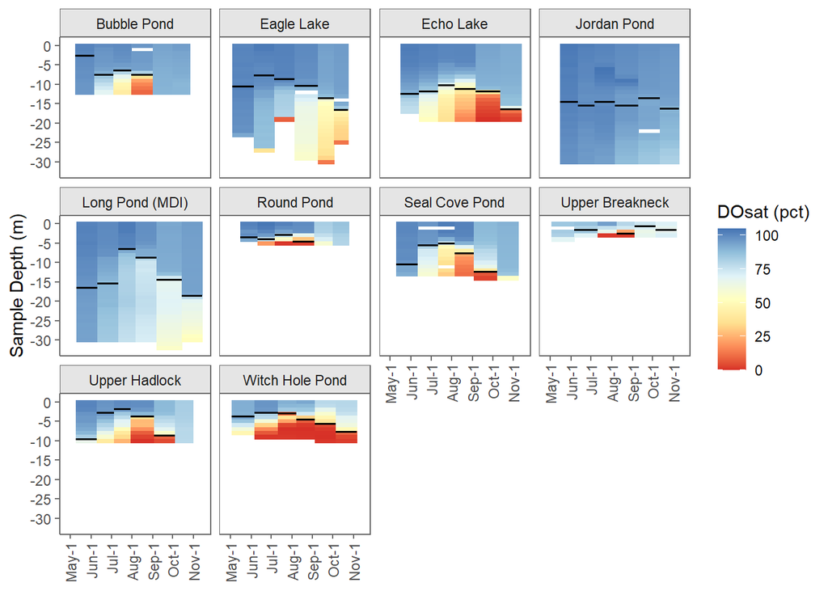

```r
plotLakeProfile(park = "ACAD", site = lakes23,
                parameter = "DOsat_pct", depth_type = 'raw', years = 2023,
                palette = 'RdYlBu', color_rev = TRUE)
```

Plot specific conductance for Seal Cove Pond from 2013 to 2023 and sample elevation. Uses spectral palette by default and adds site name as title by default. Thermocline is also plotted as default.

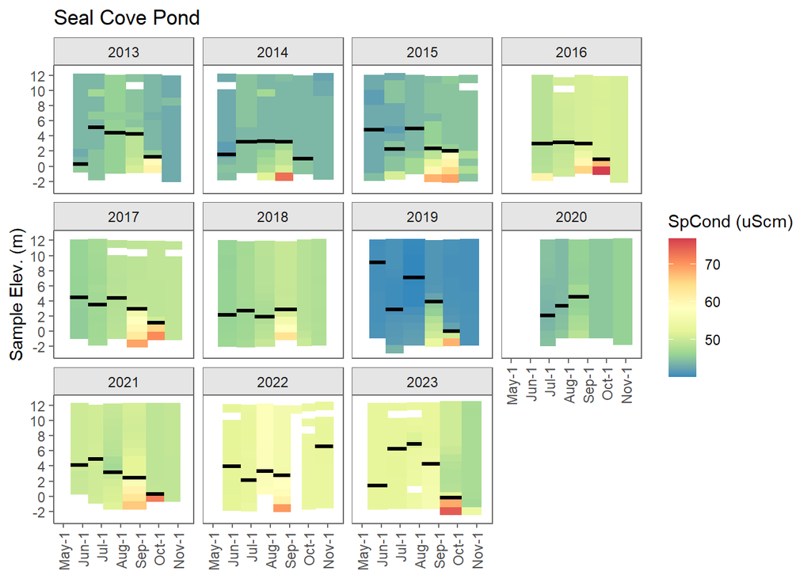

```r
plotLakeProfile(site = "ACSEAL", parameter = "SpCond_uScm",
                depth_type = 'elev', years = 2013:2023)
```

Plot pH for Jordan Pond from 2013 to 2023 and sample elevation, using reversed spectral palette.

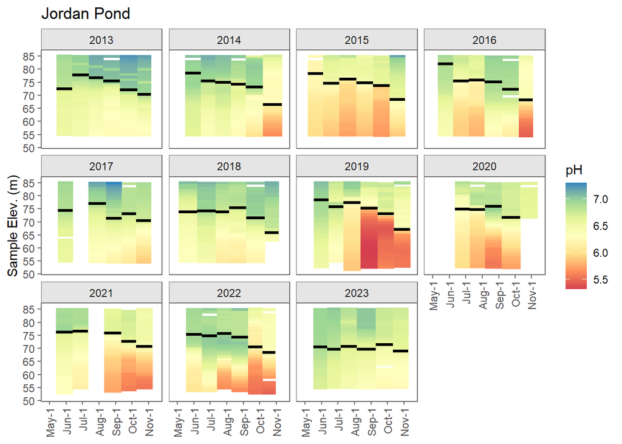

```r
plotLakeProfile(site = "ACJORD", parameter = "pH",
                depth_type = 'elev', years = 2013:2023,
                color_rev = TRUE)
```

Plot pH for all ACAD lakes sampled in 2022 and 2023 and raw sample depth, using reversed RdYlBu palette.

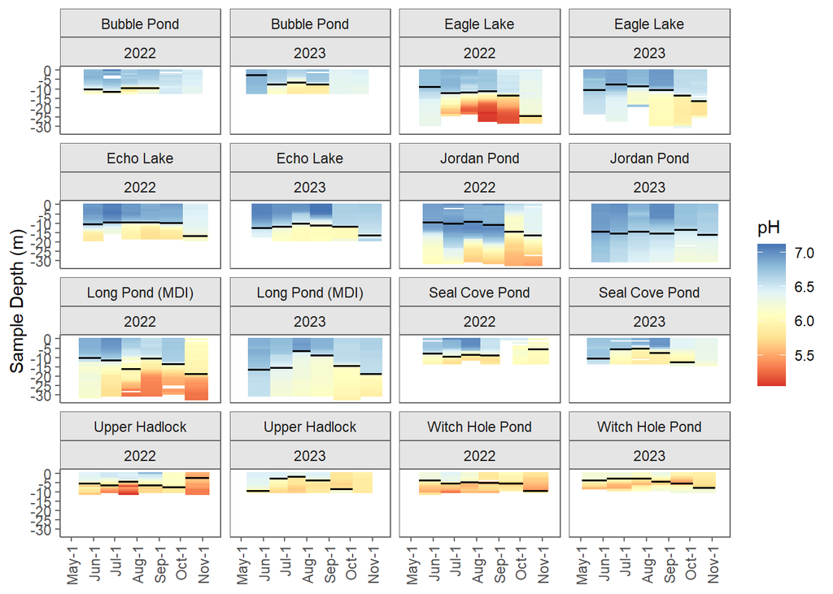

```r
plotLakeProfile(park = "ACAD", site = c("ACBUBL", "ACEAGL", "ACECHO", "ACJORD", "ACLONG", "ACSEAL",
                                        "ACUHAD", "ACWHOL"),
                parameter = "pH", depth_type = 'raw', years = 2022:2023,
                palette = 'RdYlBu', color_rev = TRUE)
```

**Combining plots**

Combine plots for temp, DO, pH, and conductance in Bubble Pond for 2023 using the `cowplot` package.

The `cowplot` package must be installed to use this code. Install the package via `install.packages('cowplot')`. There are other packages to combine plots, including `grid` and `gridExtra`, and the function `ggarrage()` in `ggpubr`. I tend to start with cowplot, because it’s easy to use and has a great [help page](https://wilkelab.org/cowplot/). If I really need to customize a plot (like custom spacing for each plot), then I use `grid/gridExtra`, which allows for more customization, but is a bit harder to work with.

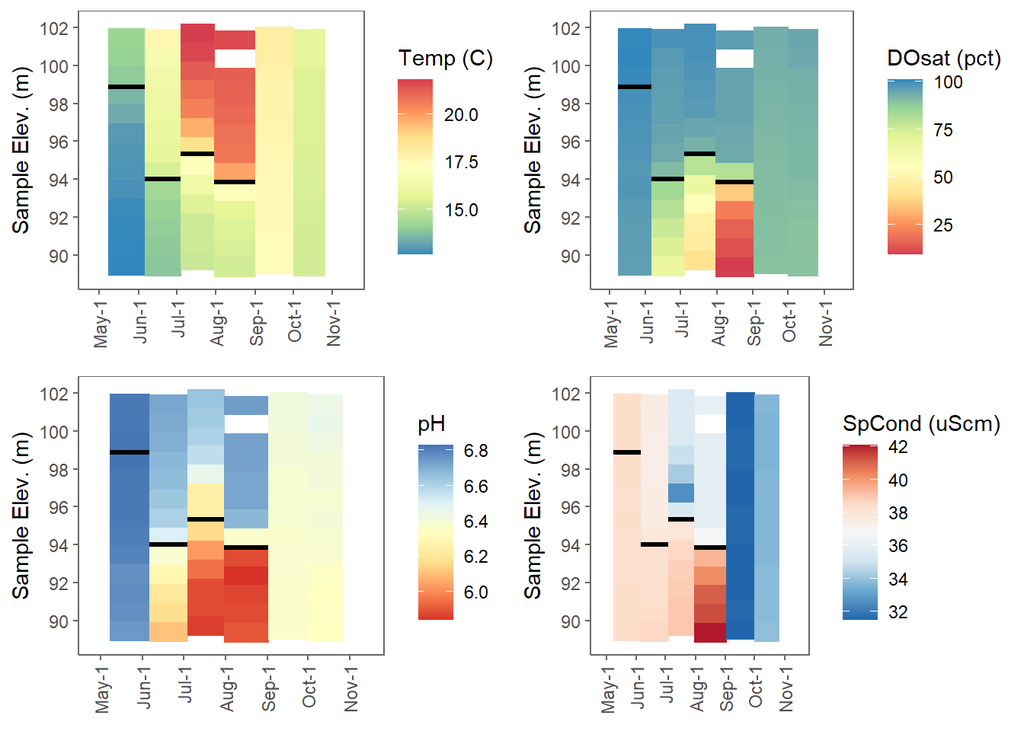

```r
library(cowplot)
sitecode = "ACBUBL"
sitename = getSites(site = sitecode)$SiteName
year = 2023
mon = 5:10
depth = 'elev'
ptitle = F

tplot <- plotLakeProfile(site = sitecode, parameter = "Temp_C", depth_type = depth,
                         years = year, months = mon, plot_title = ptitle)

doplot <- plotLakeProfile(site = sitecode, parameter = "DOsat_pct", depth_type = depth,
                          years = year, months = mon, color_rev = T, plot_title = ptitle)

pHplot <- plotLakeProfile(site = sitecode, parameter = "pH", depth_type = depth,
                          years = year, months = mon, palette = "RdYlBu", color_rev = T,
                          plot_title = ptitle)

cnplot <- plotLakeProfile(site = sitecode, parameter = "SpCond_uScm", depth_type = depth,
                         years = year, months = mon, palette = 'RdBu',
                         plot_title = ptitle)

# Default settings
plot_grid(tplot, doplot, pHplot, cnplot)
```

Same plot as above, but customize plot widths, so DO and SpCond have more space for legend, and add title above the grid.

In this case, we’re creating the plot grid with relative widths for each plot. Then we’re combining the title and the plot grid in another grid, setting the title height to be much smaller than the plot grid.

Note that sitename and year are defined in code chunk above.

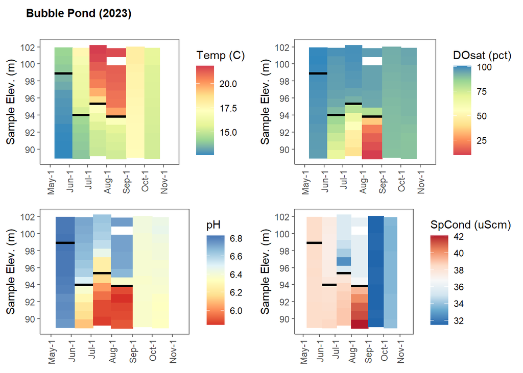

```r
title <- ggdraw() + draw_label(paste0(sitename, " (", year, ")"), size = 11, fontface = 'bold',
                               x = 0.05, hjust = 0, vjust = 0)
pgrid <- plot_grid(tplot, doplot, pHplot, cnplot, rel_widths = c(0.9, 0.95, 0.85, 1)) # doesn't seem to be working
plot_grid(title, pgrid, ncol = 1, rel_heights = c(0.1, 1))
```

#### plotPrecipDischarge()

This function produces a plot with dual y-axes, one for precipitation and one for discharge. The x-axis is date. This function only works for one stream monitoring site at a time. Note that ggplot tends to have a lot of warnings that are hard to suppress, particularly for this plot, which has a daily value for precipitation and only monthly values for discharge. You’re always going to get a message about that by using this function. Function currently only plots years where discharge is collected. Discharge is plotted as points and not lines, because discharge can change a lot between sampling events.

**Note that the climateNETN package must be installed for this function to work, as it relies on downloading daily precipitation data.** To install run `devtools::install_github("KateMMiller/climateNETN")`

Plot Discharge for Mill Brook in MIMA for past 3 years using default colors and gridlines on the y-axis and english units.

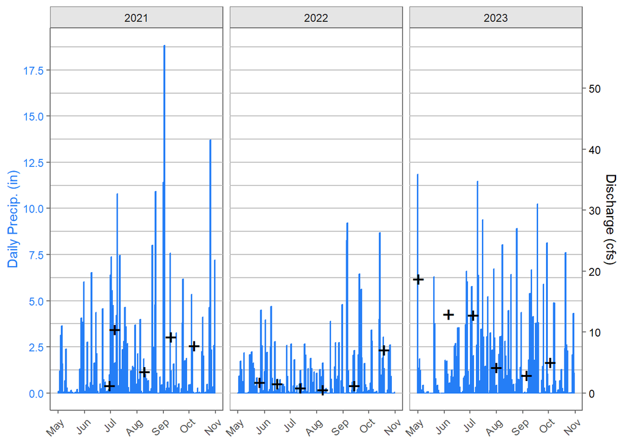

```r
plotPrecipDischarge(site = c("MIMASA"), years = 2021:2023, gridlines = "grid_y", units = "eng")
```

Plot daily precipitation vs discharge for all ROVA sites in 2021, only accepting observations of”Excellent”, “Good”, or “Fair”.

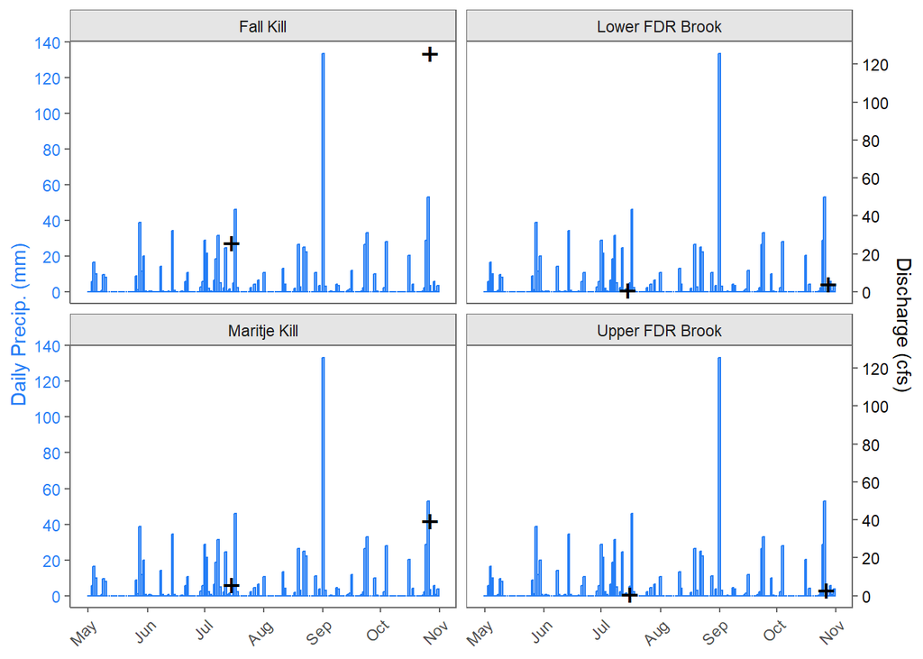

```r
plotPrecipDischarge(park = "ROVA", years = 2021, rating = c("E", "G", "F"))
```

Plot Discharge for Aunt Betty Inlet and Kebo Stream for 2024 using different colors. Note that this can be slow because has to download precip. data from NADP. LNETN parks download from a faster web service.

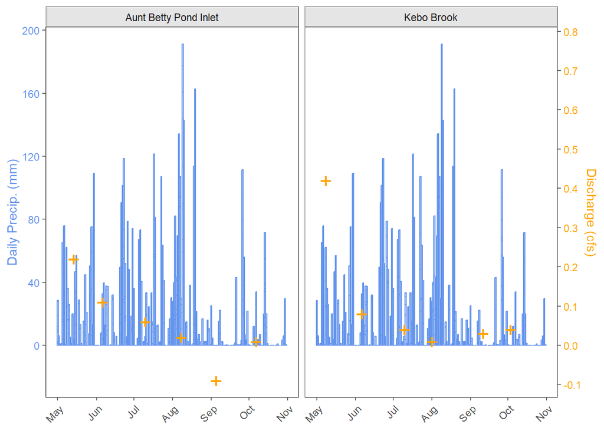

```r
plotPrecipDischarge(site = c("ACABIN", "ACKEBO"), years = 2024, palette = c("cornflowerblue", "orange"))
```

#### plotClimTrend()

**Note that this function now lives in climateNETN package**. This function produces a line or a rolling average filtered on park, year, month, and climate parameter. The default rolling average is 5-years, but you can specify a different window with the avg_window argument. If multiple parks are specified, they can either be plotted on the same figure or separate figures. If multiple parameters are specified, they will be plotted on separate figures. For multiple parks to plot on the same figure, use facet_site = FALSE. For multiple parameters on the same figure, facet_param = FALSE. Note that all months (1:12) are default. If you only want sample months, specify months = 5:10.

**NEW: I updated the compiled climate data to cover 1895 up through June 2024, so you can plot historic trends beyond just the 2006-2024 monitoring period. You can also plot units in English.**

Plot avg temp for LNETN from 1895:2024, without points and with 5-year rolling average and gridlines on y-axis, and in English units. Note that avg_window = 5 isn’t necessary, since it’s the default.

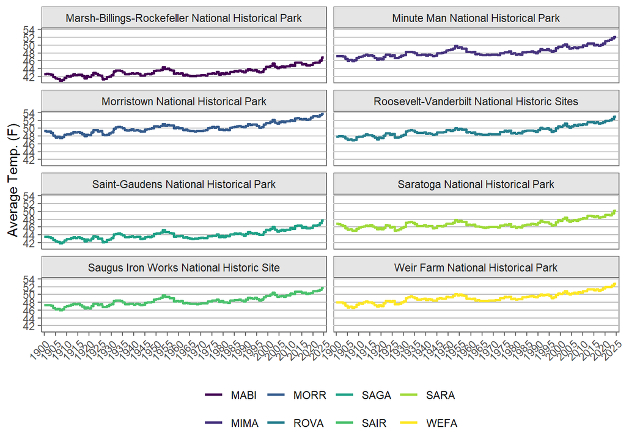

```r
climateNETN::plotClimTrend(park = "LNETN", years = 1895:2024, layers = 'rollavg',
              parameter = "tmean", palette = c("viridis"), facet_park = T,
              legend_position = 'bottom', gridlines = "grid_y", units = "eng")
```

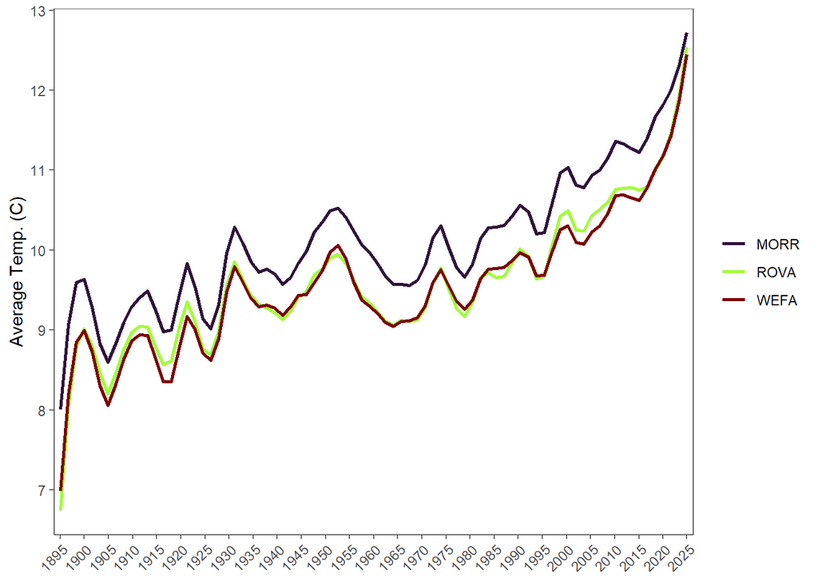

```r
climateNETN::plotClimTrend(park = c("MORR", "ROVA", "WEFA"), years = 1895:2024, layers = 'smooth',
              parameter = "tmean", span = 0.1, palette = "turbo", legend_position = 'right')
```

Plot temp stats from 1895-2024 for ACAD on the same figure.

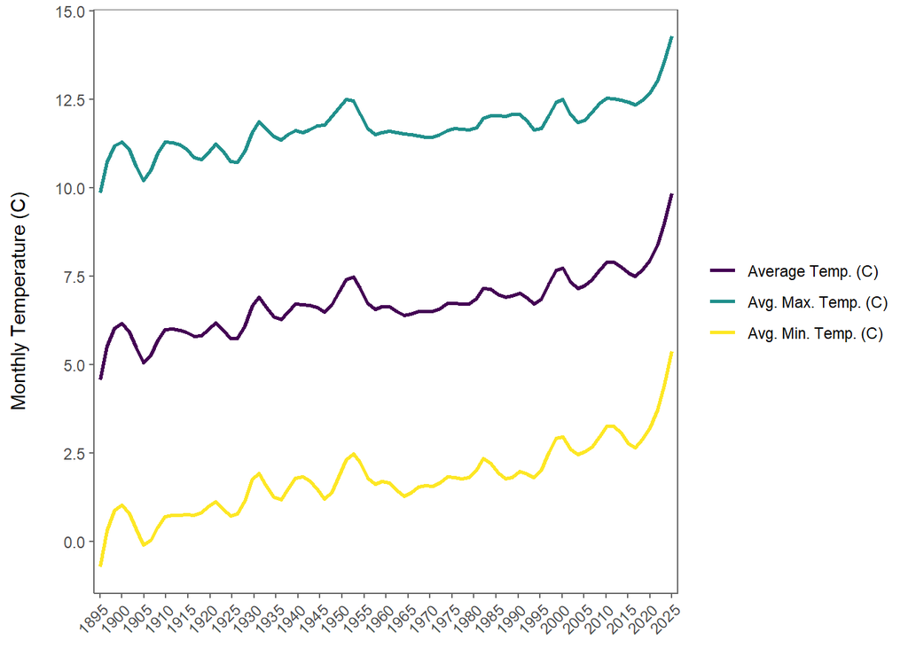

```r
climateNETN::plotClimTrend(park = "ACAD", years = 1895:2024, parameter = c("tmin", "tmean", "tmax"), span = 0.1, layers = 'smooth', facet_param = F, legend_position = 'right', palette = "viridis")
```

Plot monthly temperature data in English units for MABI from 2006:2023 (all months is default), with points and a 4-year rolling average.

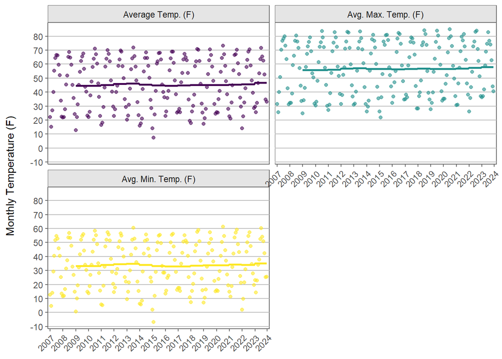

```r
climateNETN::plotClimTrend(park = "MABI", years = 2006:2023, parameter = c("tmin", "tmean", "tmax"),
                           layers = c("points", "rollavg"),
                           facet_param = T, gridlines = "grid_y", units = 'eng', avg_window = 4)
```

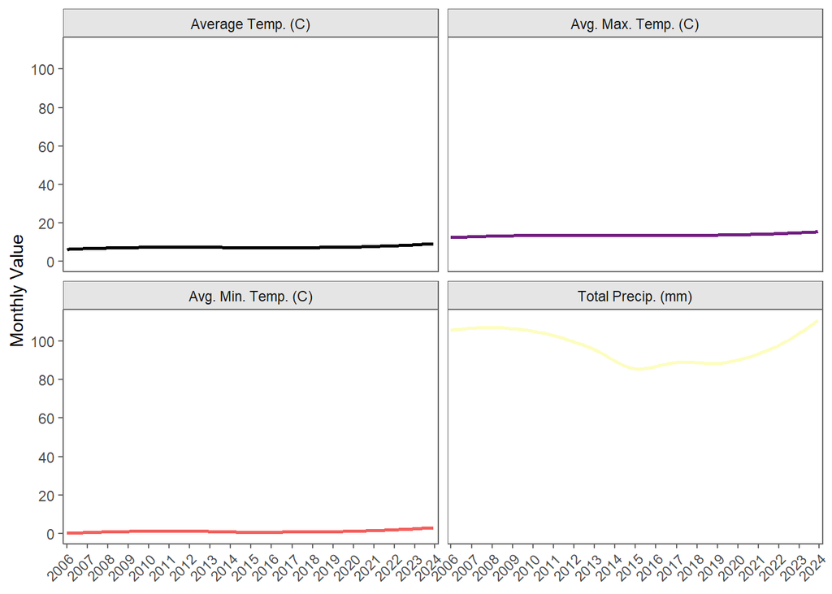

```r
climateNETN::plotClimTrend(park = "MABI", years = 2006:2023, parameter = "all", layers = 'smooth', span = 0.7, palette = "magma")
```

Plot monthly NOAA min, max and mean temperature for MABI and SARA from 2006:2024, with smoothed line, span 0.7, and parks on separate plots, but parameters on the same plots.

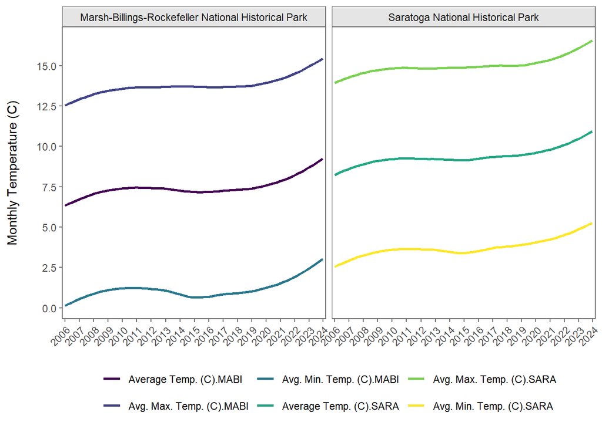

```r
climateNETN::plotClimTrend(park = c("MABI", "SARA"), years = 2006:2023,
              parameter = c("tmean", "tmax", "tmin"),
              layers = 'smooth',
              span = 0.7, facet_park = TRUE, facet_param = FALSE,
              legend_position = "bottom")
```

Plot monthly NOAA min, max and mean temperature for MABI 2006:2024, with points and smoothed line, span 0.7 with parameters on the same plots.

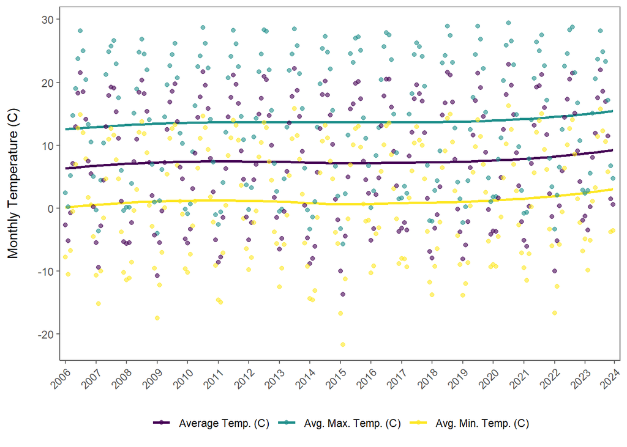

```r
climateNETN::plotClimTrend(park = "MABI", years = 2006:2023,
              parameter = c("tmean", "tmax", "tmin"),
              layers = c("points", "smooth"),
              span = 0.7, facet_param = F, legend_position = 'bottom')
```

#### plotClimAnom()

**Note that this function now lives in climateNETN package**. This function produces a trend plot filtered on park, year, month, and climate parameter and shows anomalies from chosen baseline (1901 - 2000 or 1991 - 2020) as red for above and blue for below average using gridded NOAA NClim data. If a year x month combination is specified that doesn’t occur yet in NETN_clim_annual dataset, it will be downloaded if available. New months are typically available within a few weeks of the month end. If multiple parks are specified, they can either be plotted on the same figure or separate figures. If multiple parameters are specified, they will be plotted on separate figures.You can also plot percent difference of precipitation, in addition to difference in raw units (i.e. mm).

Plot ACAD average temperature anomalies from 1895 to 2024 compared with 20th century normals with gridlines on y axis and English units.

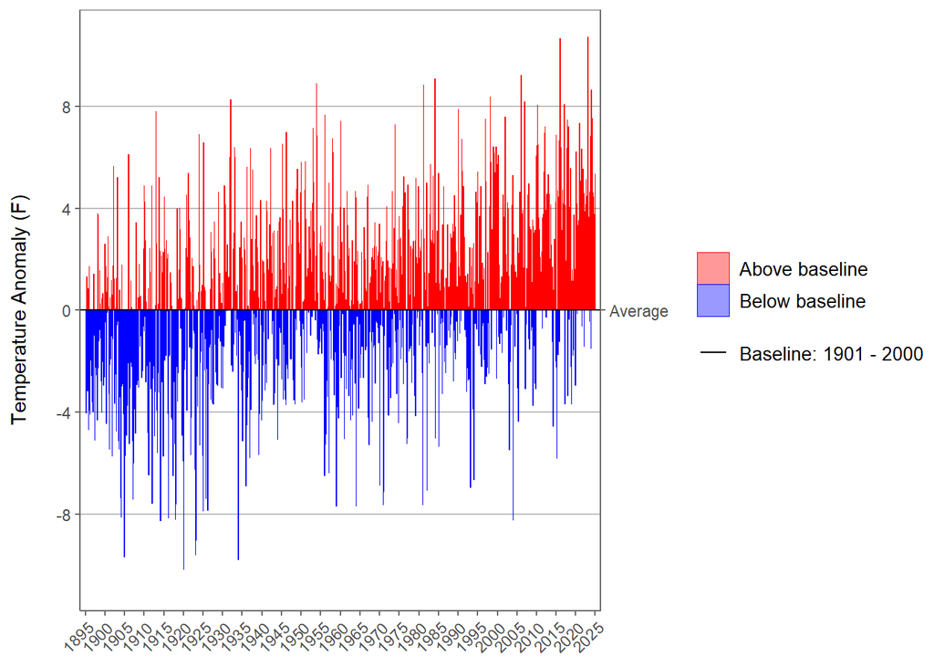

```r
climateNETN::plotClimAnom(park = "ACAD", years = 1895:2024, parameter = "tmean",
             legend_position = 'right', gridlines = "grid_y", units = "eng")
```

Plot WEFA percent precipitation anomalies in 2023 compared with 20th century normals.

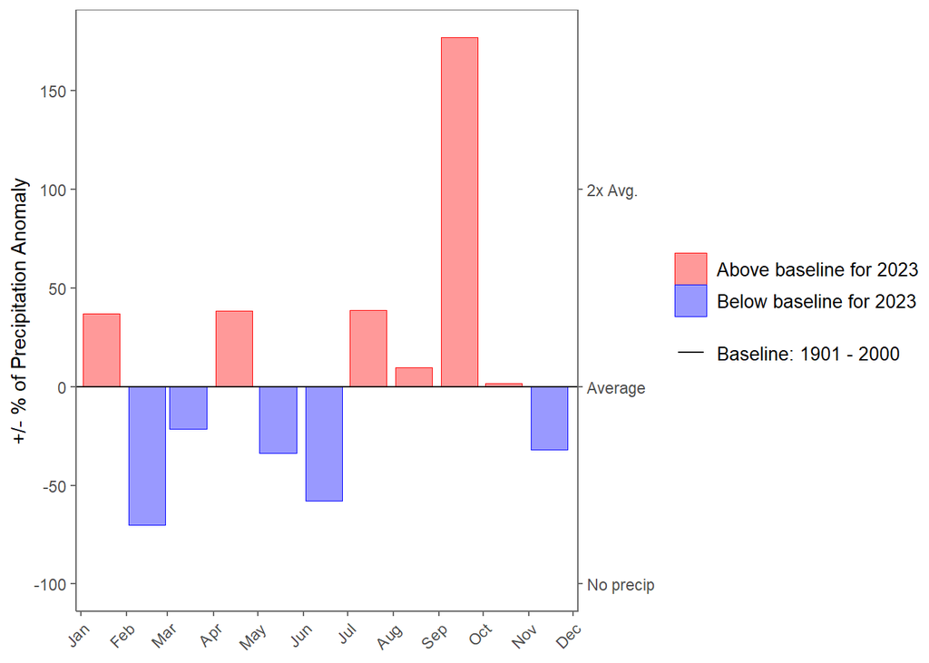

```r
climateNETN::plotClimAnom(park = "WEFA", years = 2023, parameter = "ppt_pct", legend_position = 'right')
```

Plot MABI and SAGA average temperature anomalies from 2006 to 2024 compared with 20th century normals.

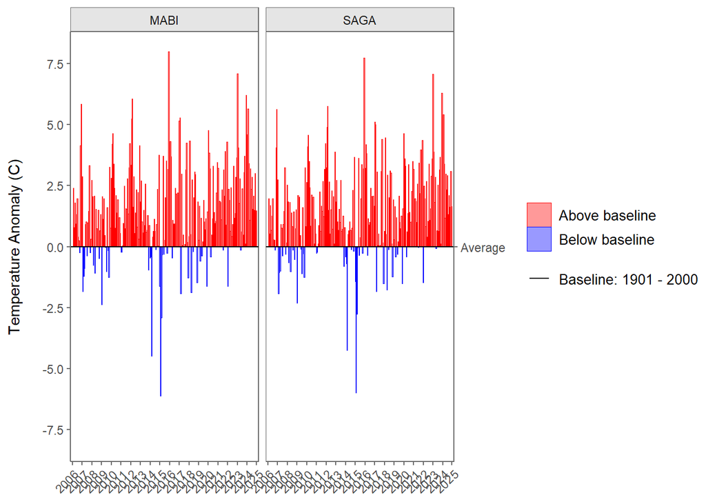

```r
climateNETN::plotClimAnom(park = c("MABI", "SAGA"), years = 2006:2024, parameter = "tmean", legend_position = 'right')
```

Plot MABI and SAGA precip. anomalies from 2023 compared with 20th century normals.

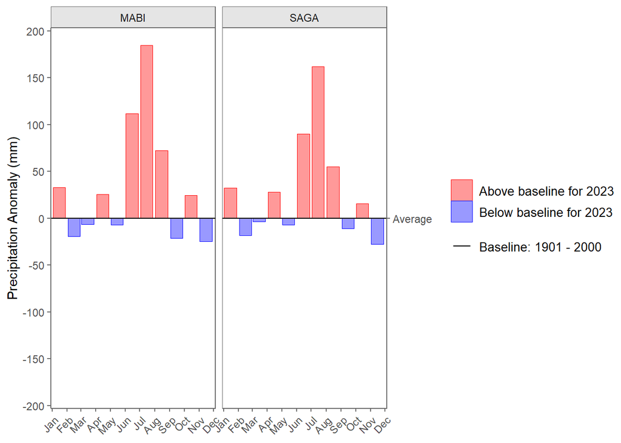

```r
climateNETN::plotClimAnom(park = c("MABI", "SAGA"), years = 2023, parameter = "ppt", legend_position = 'right')
```

Plot ACAD avg temp anomalies from last 20 years compared with 30-year normals.

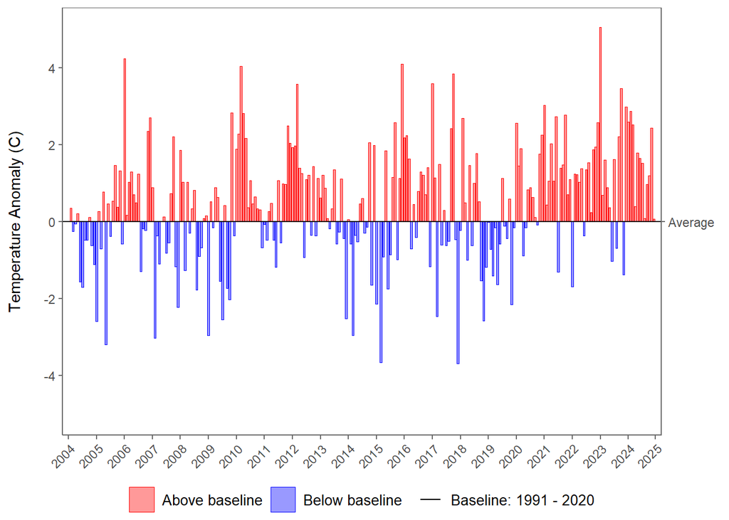

```r
climateNETN::plotClimAnom(park = c("ACAD"), years = 2004:2024, parameter = "tmean",
             legend_position = 'bottom', normal = "norm1990")
```

#### plotClimComps()

**Note that this function now lives in climateNETN package**. This function compares either the 20th century normals (1901 - 2000), or the most recent 30-year normal (1991 - 2020) average monthly climate variables with user-specified years to provide an idea of how extreme or normal a given month in a year is.

**This function has been overhauled to work with NOAA gridded climate data for both the normals and the current data.** The same algorithms are used to generate historic and current data, which minimizes the bias introduced by weather station vs. Daymet data (Prism had similar issues). Using the NOAA dataset is slower to process, so I went with park-level centroids to extract climate data instead of extracting at the site level. I also compiled all of the NOAA data from 1895 through May 2024. I have a webalert that tells me when a new month is available, so I can keep the compiled data up to date (see `data("NETN_clim_annual")`). However, if I get behind, this function will download the missing months of data that are available online.

You can now add gridlines to x, y, or both axes.

**Single parameter**

Plot mean monthly temp for MABI for 2019:2023 and all months with red-blue color palette and the 20th century normal with gridlines on y in english units.

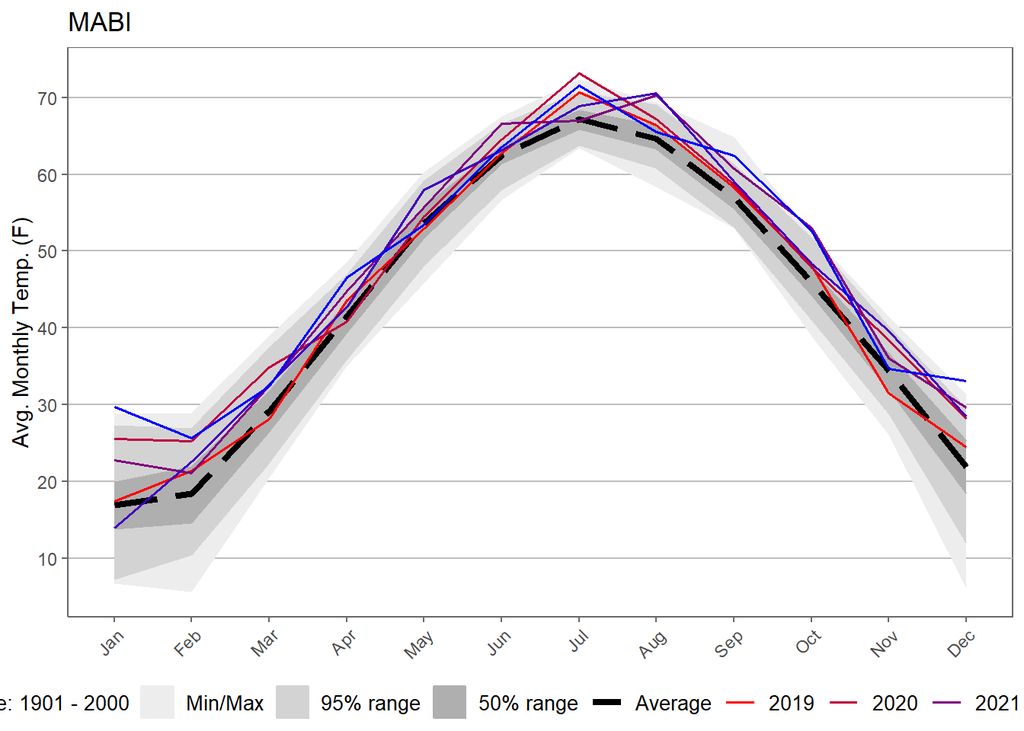

```r
climateNETN::plotClimComps(park = "MABI", years = 2019:2023, parameter = "tmean",
              palette = c("red", "blue"), normal = "norm20cent",
              gridlines = 'grid_y', units = "eng", legend_position = 'bottom')
```

Same as above, but with points and 30-year normal starting at 1991.

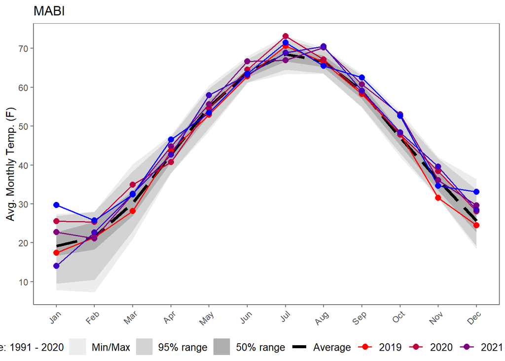

```r
climateNETN::plotClimComps(park = "MABI", years = 2019:2023, parameter = "tmean",
                           palette = c("red", "blue"),
              layers = c('points', 'lines'), normal = "norm1990", units = 'eng',
              legend_position = 'bottom')
```

Plot max monthly temp for ROVA for 2023 and 2024, with orange-blue palette and 20th century norm (default) using scientific units.

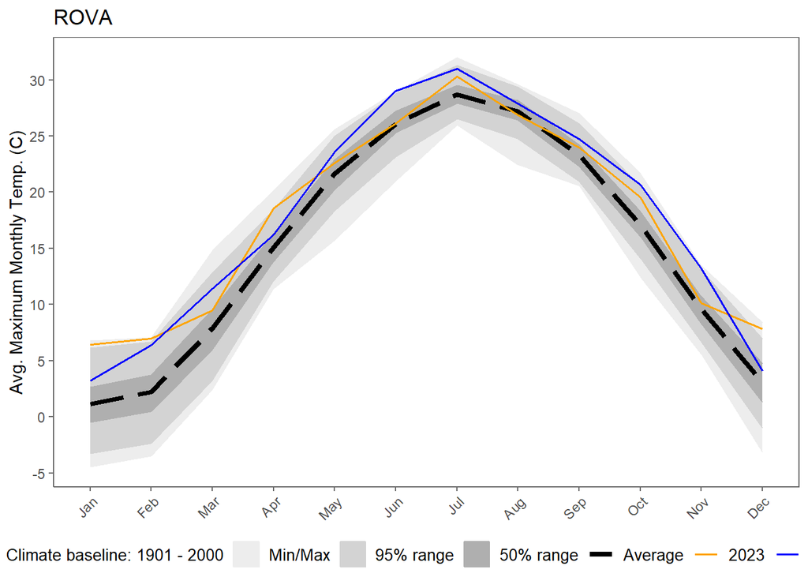

```r
climateNETN::plotClimComps(park = "ROVA", years = 2023:2024, parameter = "tmax",
              palette = c("orange", "blue"), layers = 'lines', legend_position = 'bottom')
```

Plot total monthly precip for Jordan Pond for past 5 years using orange-blue color palette, compared with the 30-year norm starting at 1990.

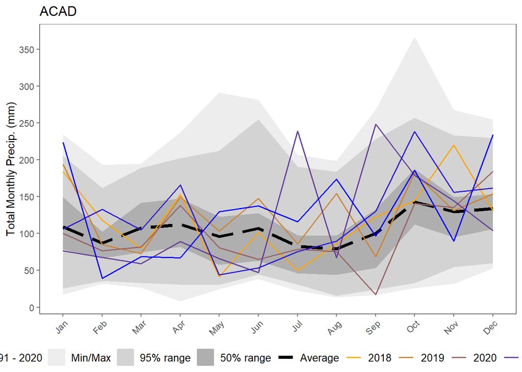

```r
climateNETN::plotClimComps(park = "ACAD", years = 2018:2023, parameter = 'ppt',
              palette = c("orange","blue"), normal = "norm1990", legend_position = 'bottom')
```

Plot total monthly precip for ACAD for current year using red for 2023 and blue for 2024

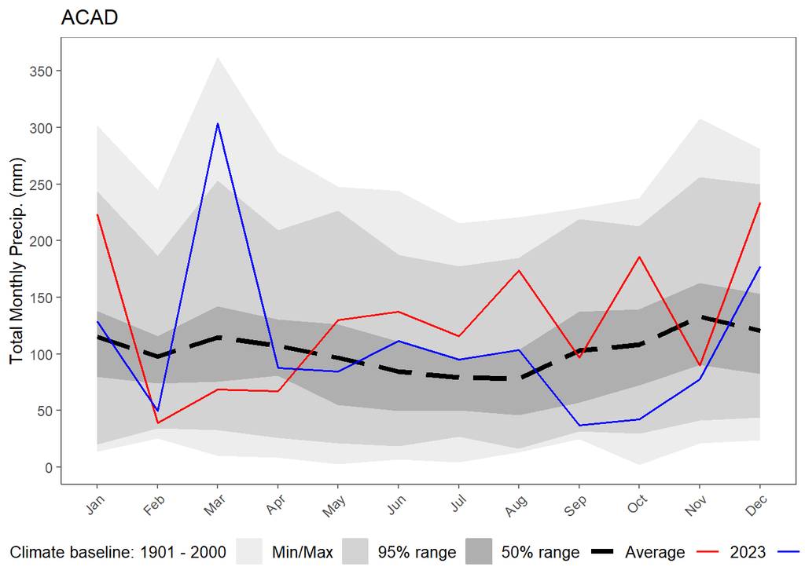

```r
climateNETN::plotClimComps(park = "ACAD", years = 2023:2024, parameter = 'ppt',
                           palette = c("red", "blue"), legend_position = 'bottom')
```

Plot total monthly max temp for ACAD for current year using red for current year color and 30-year normal.

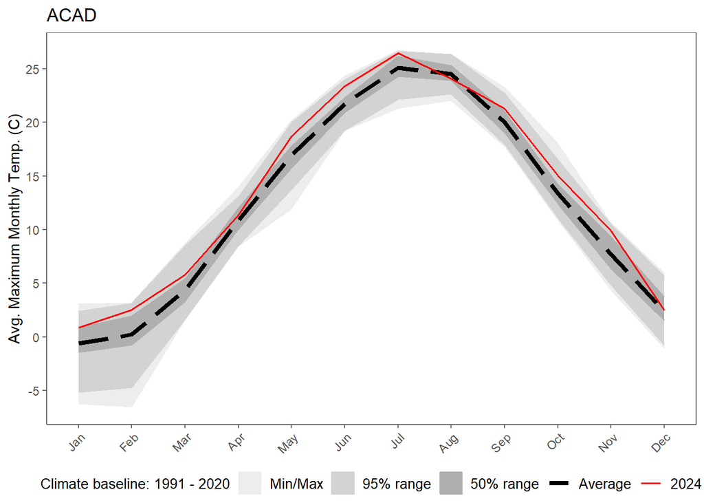

```r
climateNETN::plotClimComps(park = "ACAD", years = 2024, parameter = 'tmax',
                           palette = c("red"), normal = "norm1990", legend_position = 'bottom')
```

**Multiple plots**

The code below would take a lot to program into waterNETN functions, so I’m instead showing you how you can create panels of multiple plots using the cowplot package.

Generate grid of all parameters in ACAD from past 5 years

Note that the code that names leg is extracting a legend from a copy of the figures to be plotted separately from the other figures. This allows you to control the sizing and alignment better. The NULLs also allow you to create white space between plots.

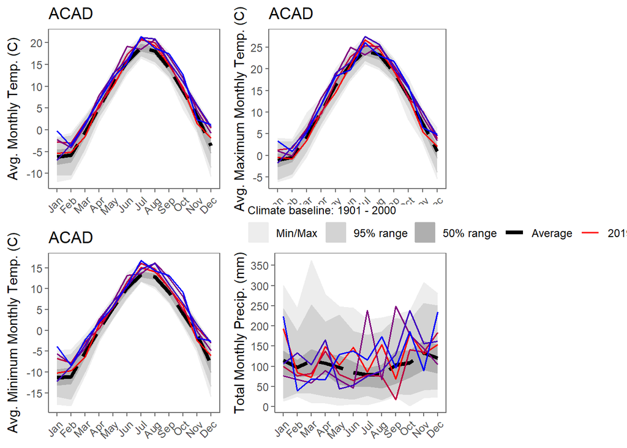

```r
tmax <- climateNETN::plotClimComps(
  park = "ACAD", years = 2019:2023, parameter = "tmax",
  layers = 'lines', legend_position = 'none', palette = c("red", "blue"))

tmin <- climateNETN::plotClimComps(
  park = "ACAD", years = 2019:2023, parameter = "tmin",
  layers = 'lines', legend_position = 'none', palette = c("red", "blue"))
tmean <- climateNETN::plotClimComps(
  park = "ACAD", years = 2019:2023, parameter = "tmean",
  layers = 'lines', legend_position = 'none', palette = c("red", "blue"))
prec <- climateNETN::plotClimComps(
  park = "ACAD", years = 2019:2023, parameter = 'ppt',
  layers = 'lines', legend_position = 'none', palette = c("red", "blue"))

prec_leg <- climateNETN::plotClimComps(park = "ACAD", years = 2019:2023, parameter = 'tmax',
                          layers = 'lines', legend_position = 'right', palette = c("red", "blue")) +
 theme(legend.box.margin = margin(0, 0, 0, 5),
       legend.text = element_text(size = 9),
       legend.title = element_text(size = 9))

leg <- cowplot::get_plot_component(
  prec_leg,
  'guide-box-right',
  return_all = T
  )


grid1 <- cowplot::plot_grid(tmean, tmax, NULL, tmin, prec, NULL,
                            nrow = 2, ncol = 3, rel_widths = c(1, 1, 0.05, 1, 1, 0.05))
grid2 <- cowplot::plot_grid(grid1, NULL, leg, ncol = 3, nrow = 1, rel_widths = c(1, 0.05, 0.3))
grid2
```

Because waterNETN plotting functions return ggplot objects, we can tweak the plots so that temp plots all have the same y axis (so you can see that max is higher than min).

```r
data("NETN_clim_annual") # compiled annual data
data("NETN_clim_norms") # compiled normals
head(NETN_clim_annual)
```

```
##   UnitCode
## 1     ACAD
## 2     BOHA
## 3     ROVA
## 4     MABI
## 5     MIMA
## 6     MORR
##                                              UnitName
## 1                                Acadia National Park
## 2      Boston Harbor Islands National Recreation Area
## 3        Roosevelt-Vanderbilt National Historic Sites
## 4 Marsh-Billings-Rockefeller National Historical Park
## 5                 Minute Man National Historical Park
## 6                 Morristown National Historical Park
##        long
```

[output cut: 55 more lines]

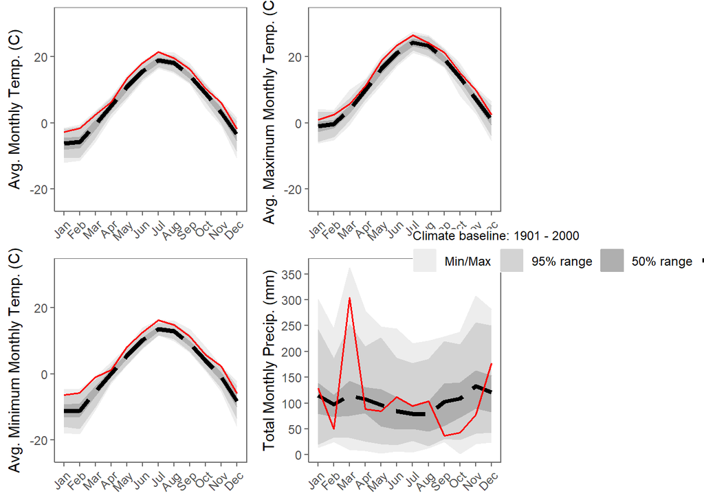

```r
ymin <- round(min(NETN_clim_annual$tmin, NETN_clim_norms$tmin_norm_1901_2000,
                  NETN_clim_norms$tmin_norm_1991_2020), 0) - 1
ymax <- round(max(NETN_clim_annual$tmax, NETN_clim_norms$tmax_norm_1901_2000,
                  NETN_clim_norms$tmax_norm_1991_2020), 0) -1

tmax <- climateNETN::plotClimComps(park = "ACAD", years = 2024, parameter = "tmax", data_type = "wstn",
                      layers = 'lines', legend_position = 'none', palette = c("red", "blue"),
                      plot_title = F) +
        ylim(ymin, ymax)
tmin <- climateNETN::plotClimComps(park = "ACAD", years = 2024, parameter = "tmin", data_type = "wstn",
                      layers = 'lines', legend_position = 'none', palette = c("red", "blue"),
                      plot_title = F) +
        ylim(ymin, ymax)
tmean <- climateNETN::plotClimComps(park = "ACAD", years = 2024, parameter = "tmean", data_type = "wstn",
                       layers = 'lines', legend_position = 'none', palette = c("red", "blue"),
                      plot_title = F)+
        ylim(ymin, ymax)
prec <- climateNETN::plotClimComps(park = "ACAD", years = 2024, parameter = 'ppt', data_type = "wstn",
                      layers = 'lines', legend_position = 'none', palette = c("red", "blue"),
                      plot_title = F)

prec_leg <- climateNETN::plotClimComps(park = "ACAD", years = 2024, parameter = 'tmax', data_type = "wstn",
                          layers = 'lines', legend_position = 'right',
                          palette = c("red", "blue")) +
 theme(legend.box.margin = margin(0, 0, 0, 5),
       legend.text = element_text(size = 9),
       legend.title = element_text(size = 9))

leg <- cowplot::get_plot_component(
  prec_leg,
  'guide-box-right',
  return_all = T
  )


grid1 <- cowplot::plot_grid(tmean, tmax, NULL, tmin, prec, NULL,
                            nrow = 2, ncol = 3, rel_widths = c(1, 1, 0.05, 1, 1, 0.05))
grid2 <- cowplot::plot_grid(grid1, NULL, leg, ncol = 3, nrow = 1, rel_widths = c(1, 0.05, 0.3))
grid2
```

#### plotClimCumPrecip()

**Note that this function now lives in climateNETN package**. This function plots cumulative monthly precipitation for a given year compared to either the 19th century or 30-year normal. If multiple parks or years are specified, resulting plots will be faceted on those variables.You can add gridlines to the x, y or both axes.

Plot ACAD cumulative precipitation for 2020 through 2023 with gridlines on y axis and precip in inches.

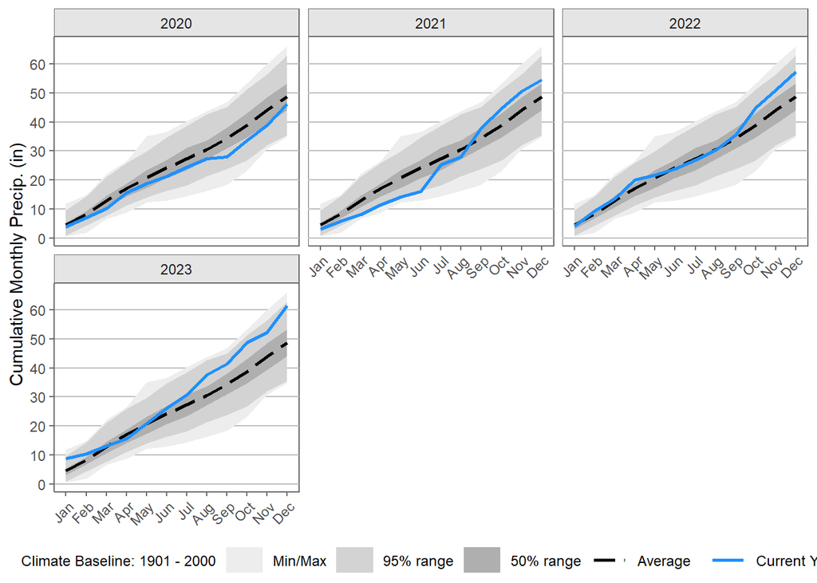

```r
climateNETN::plotClimCumPrecip(park = "ACAD", years = 2020:2023, legend_position = 'bottom',
                  gridlines = "grid_y", units = 'eng')
```

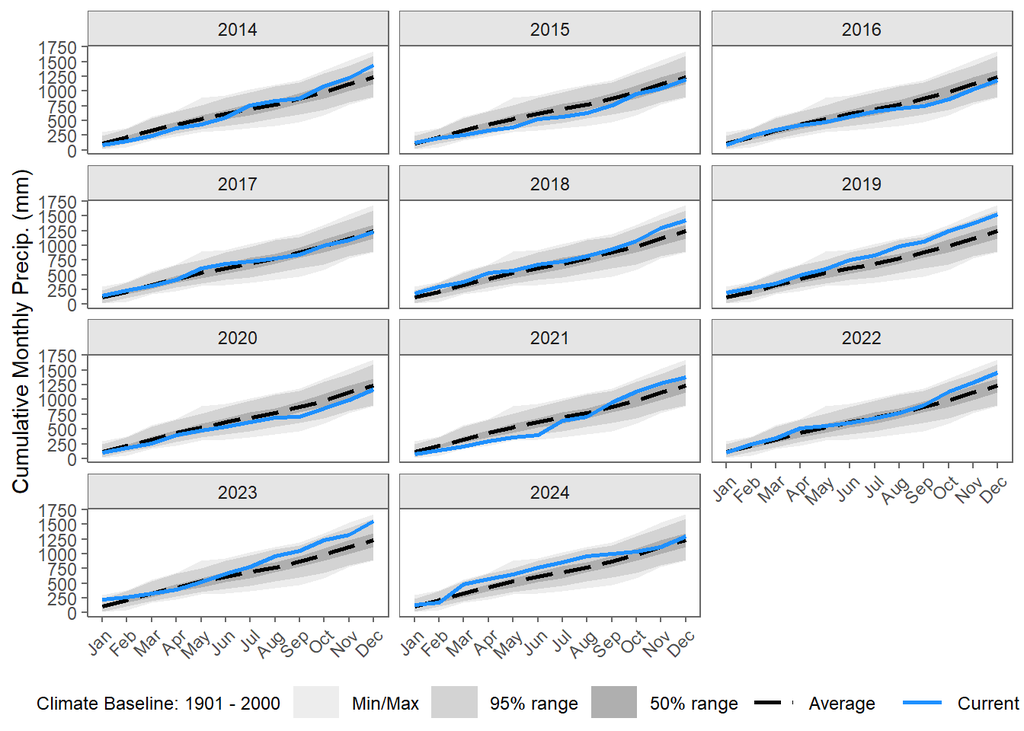

```r
climateNETN::plotClimCumPrecip(park = "ACAD", years = 2014:2024, legend_position = 'bottom')
```

Plot all but SAIR cumulative precipitation for 2023 with 4 columns

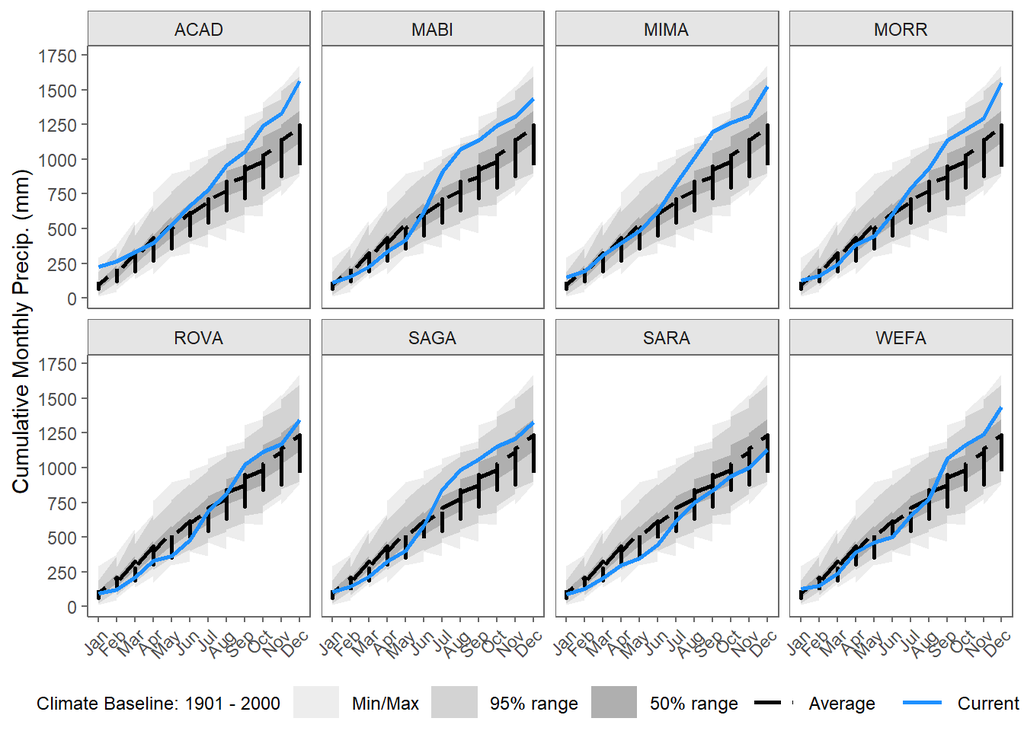

```r
parks <- c("ACAD", "MABI", "MIMA", "MORR", "ROVA", "SAGA", "SARA", "WEFA")
climateNETN::plotClimCumPrecip(park = parks, years = 2023, legend_position = 'bottom', numcol = 4)
```

Plot cumulative precipitation for 2019 - 2023

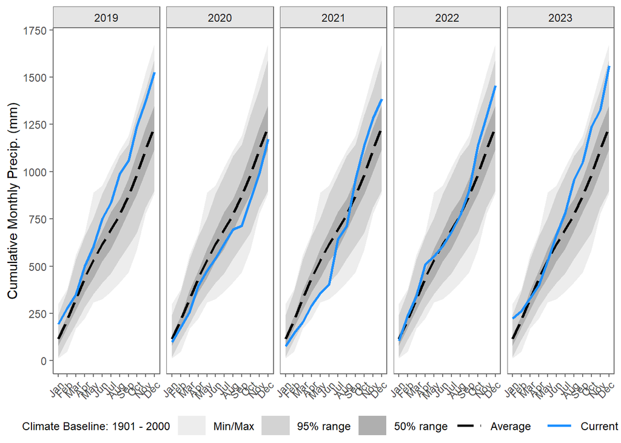

```r
climateNETN::plotClimCumPrecip(park = "ACAD", years = 2019:2023, legend_position = 'bottom', numcol = 5)
```

#### plotClimRel()

**Note that this function now lives in climateNETN package**. This function plots a given year compared against either the 19th century normal (1901 - 2000) or the 1991 - 2020 normal. Both normals and annual comparisons are derived from NOAA gridded climate data. You can either plot all temp variables, min/max temp, mean temp or precipitation. If multiple years are specified, resulting plots will facet on year. You can make your own palette by specifying colors, or by default use viridis. Currently can only plot one park at a time. Can also add gridlines to x, y or both axes.

Plot all temperature variables on 1 graph for MABI in 2024 with gridlines on y axis and english units.

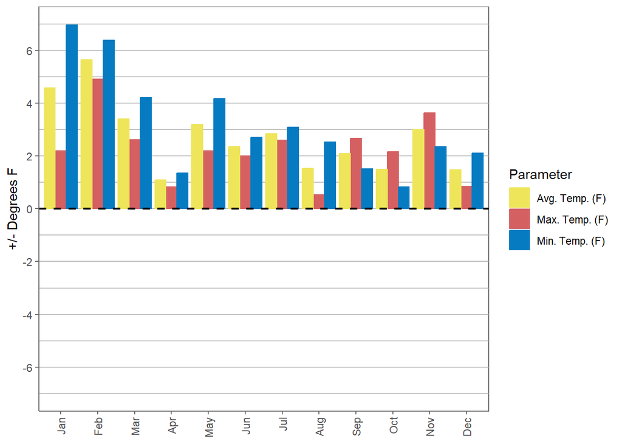

```r
climateNETN::plotClimRel(park = "MABI", years = 2024, parameter = "temp", units = "eng",
            palette = c("#EEE55A", "#D56062", "#067BC2"), gridlines = 'grid_y')
```

Plot precip for SARA 2023 compared to 1990 - 2019 normals.

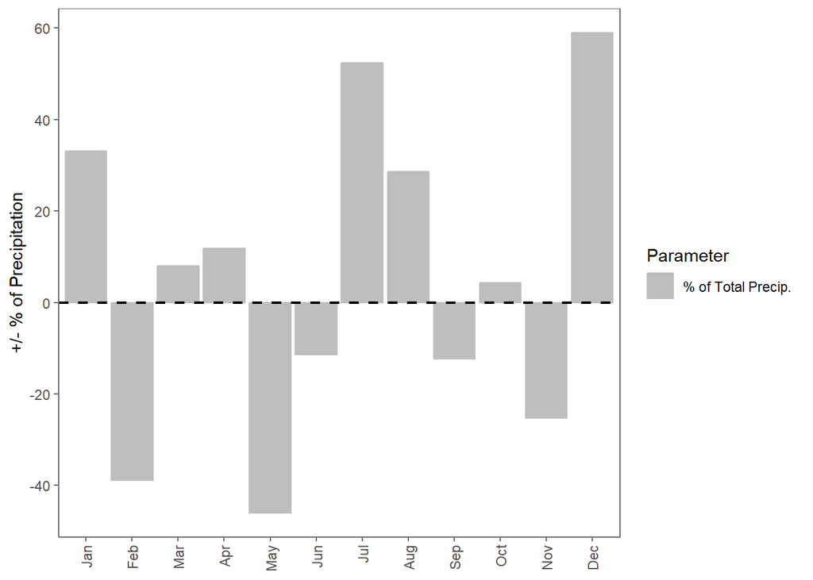

```r
climateNETN::plotClimRel(park = "SARA", years = 2023, parameter = "ppt", palette = "grey", normal = "norm1990")
```

Plot precip for SARA 2023 and 2024 compared to 1990 - 2019 normals.

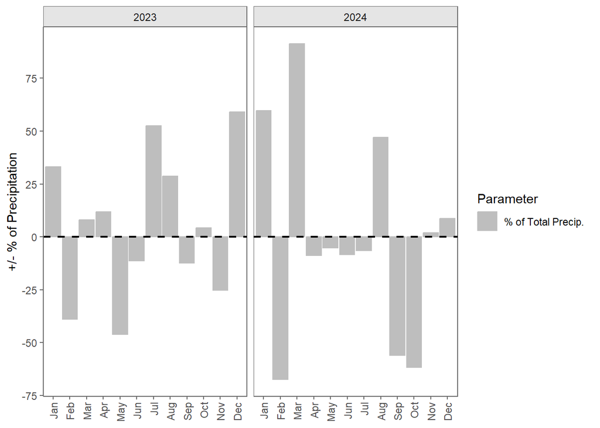

```r
climateNETN::plotClimRel(park = "SARA", years = 2023:2024, parameter = "ppt",
            palette = "grey", normal = "norm1990")
```

Plot precip for LNETN parks in 2023 without a legend and with 4 columns instead of 3.

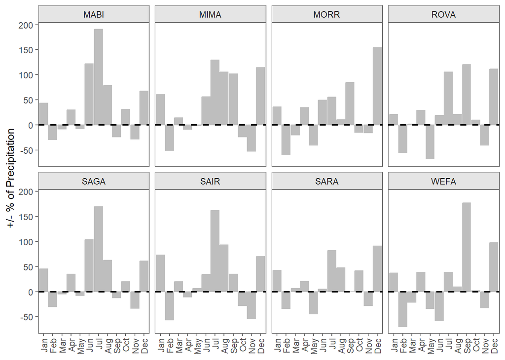

```r
climateNETN::plotClimRel(park = "LNETN", years = 2023, parameter = "ppt", palette = "grey", legend_position = 'none', numcol = 4)
```

Same as above, but with full park names as facet titles.

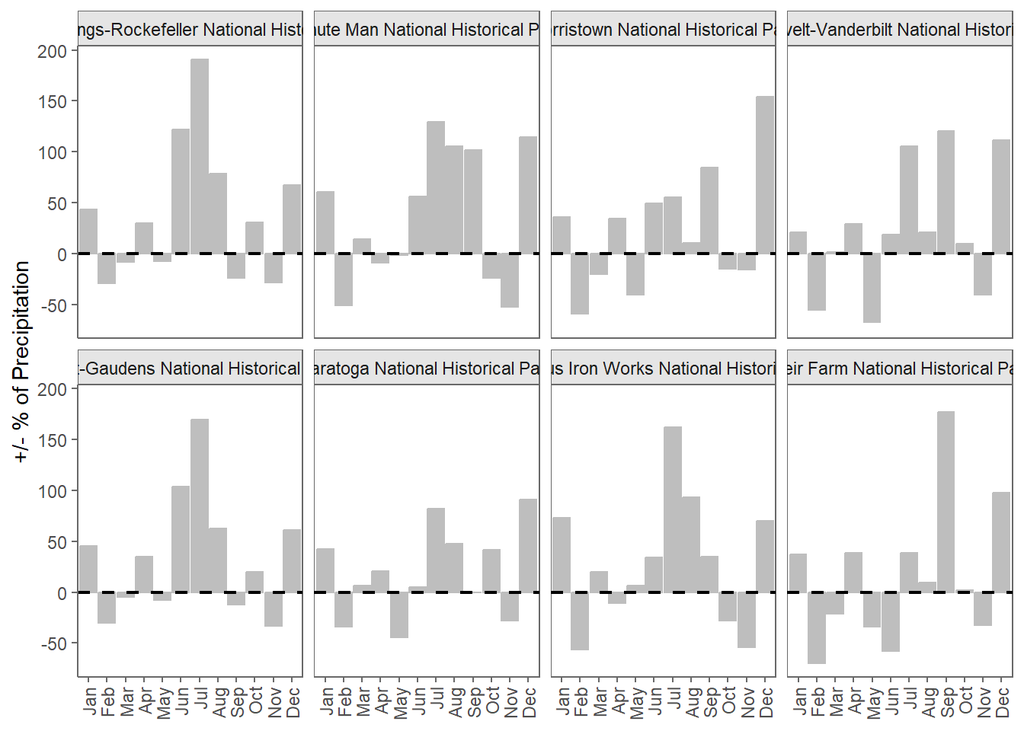

```r
climateNETN::plotClimRel(park = "LNETN", years = 2023, parameter = "ppt", palette = "grey", legend_position = 'none', numcol = 4, title_type = "UnitName")
```

#### plotClimDrought()

**Note that this function now lives in climateNETN package**. This function plots weekly drought index at the county level for each specified park or weather station nearest to a specified park. Resulting plot shows the percent of county area in 5 levels of drought, with D0 = Abnormally Dry, D1 = Moderate Drought, D2 = Severe Drought, D3 = Extreme Drought, and D4 = Exceptional Drought. Drought designations come from the U.S. Drought Monitor. If multiple parks are specified, results will be faceted with a separate plot for each park. Where multiple counties occur in a park, data can be faceted by county if `dom_county = FALSE`. To only plot predominant county, specify `dom_county = TRUE` (default).

I tweaked the x-axis formatting a bit based on whether 1 year or many years are plotted. Let me know if you’d like further tweaks. You can also now add gridlines.

Plot drought info for ACAD in 2023 wiht gridlines on y axis

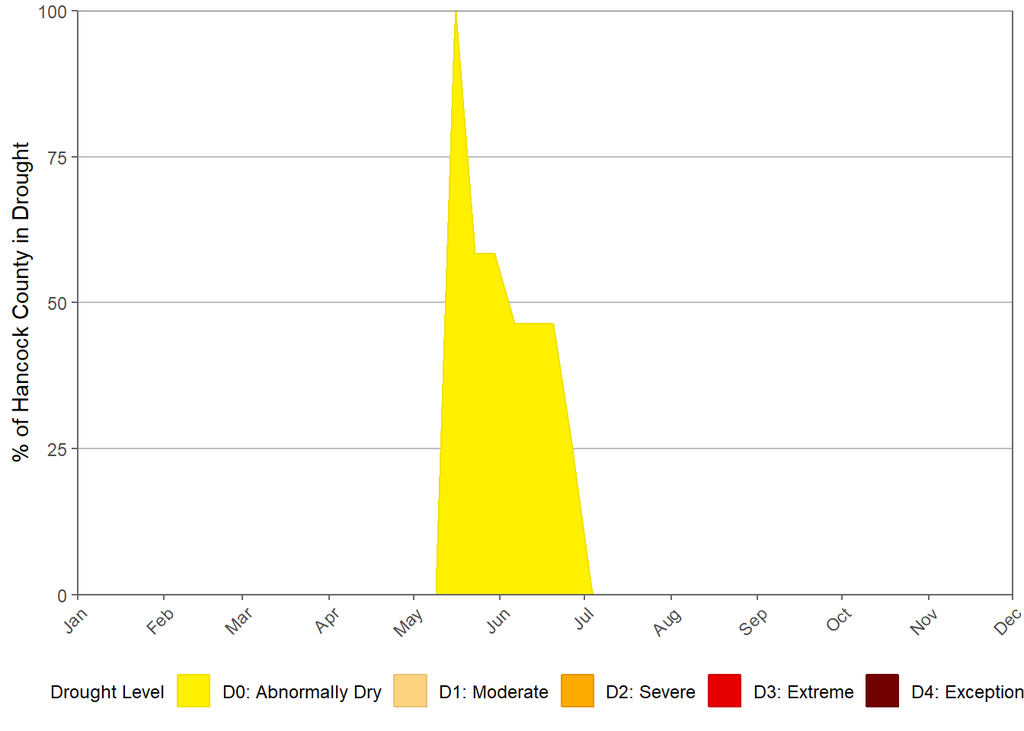

```r
climateNETN::plotClimDrought(park = c("ACAD"), years = 2023, gridlines = "grid_y", legend_position = 'bottom')
```

Plot drought info for MABI and SAGA for 2020 to 2024 with gridlines on x axis.

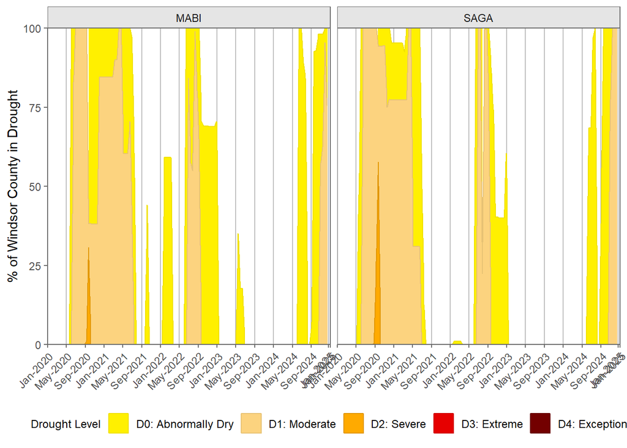

```r
climateNETN::plotClimDrought(park = c("MABI", "SAGA"), years = 2020:2024, gridlines = "grid_x", legend_position = 'bottom')
```

Plot drought info for both MORR counties for 2023

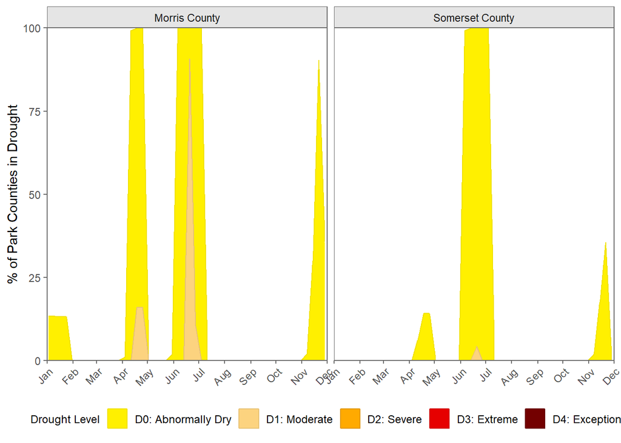

```r
climateNETN::plotClimDrought(park = "MORR", years = 2023, dom_county = FALSE, legend_position = "bottom")
```

Plot drought info for both ACAD counties in 2020 for May through October

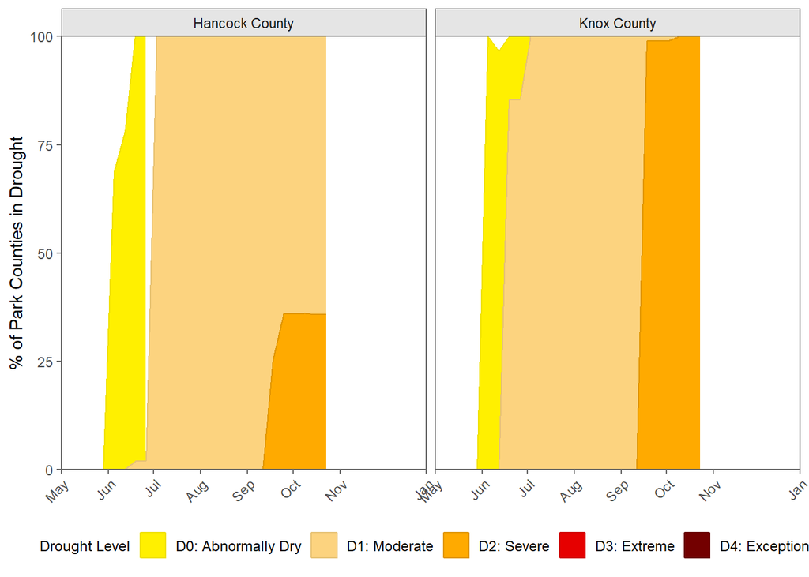

```r
climateNETN::plotClimDrought(park = "ACAD", years = 2020, dom_county = FALSE, months = 5:10, legend_position = "bottom")
```

Plot drought info for MABI, SAGA, and SARA in 2023 with legend on bottom

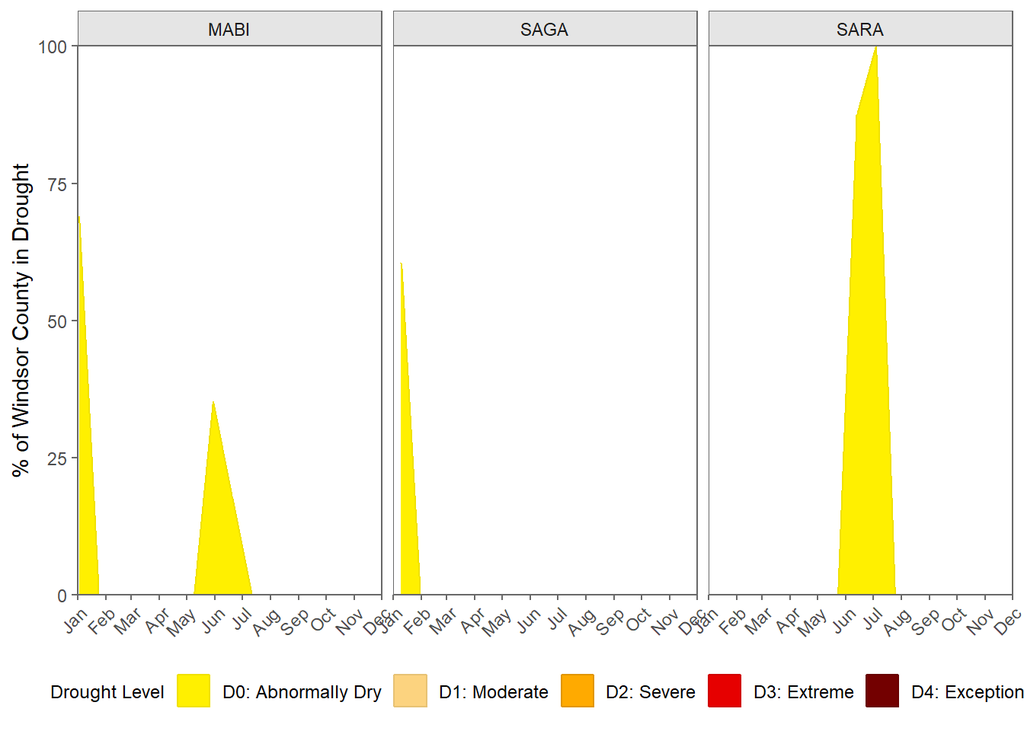

```r
climateNETN::plotClimDrought(park = c("MABI", "SAGA", "SARA"), years = 2023, legend_position = 'bottom')
```

### Summary Functions

#### sumEvents()

Summarize number of samples collected per park, site, month, and parameter. Resulting data frame show number of samples collected for each month, and whether the value is real (month) or censored (month_cens).

Summarize all events for ACAD for all years and active sites

```r
acad_ev <- sumEvents(park = "ACAD")
print_head(acad_ev)
```

| UnitCode | SiteType | SiteName | param_type | Parameter | year_range | num_years | May | Jun | Jul | Aug | Sep | Oct | May_cens | Jun_cens | Jul_cens | Aug_cens | Sep_cens | Oct_cens |
| --- | --- | --- | --- | --- | --- | --- | --- | --- | --- | --- | --- | --- | --- | --- | --- | --- | --- | --- |
| ACAD | Lake | Aunt Bettys Pond | Lab chemistry | ANC_ueqL | 2006 – 2024 | 7 | 0 | 4 | 0 | 4 | 0 | 0 | 0 | 0 | 0 | 0 | 0 | 0 |
| ACAD | Lake | Aunt Bettys Pond | Lab chemistry | ChlA_ugL | 2006 – 2024 | 7 | 3 | 7 | 3 | 7 | 3 | 3 | 0 | 0 | 0 | 0 | 0 | 0 |
| ACAD | Lake | Aunt Bettys Pond | Lab chemistry | DOC_mgL | 2006 – 2024 | 7 | 3 | 5 | 3 | 5 | 3 | 3 | 0 | 0 | 0 | 0 | 0 | 0 |
| ACAD | Lake | Aunt Bettys Pond | Lab chemistry | TN_mgL | 2006 – 2024 | 7 | 3 | 7 | 3 | 7 | 3 | 3 | 0 | 0 | 0 | 0 | 0 | 0 |
| ACAD | Lake | Aunt Bettys Pond | Lab chemistry | TP_ugL | 2006 – 2024 | 7 | 3 | 7 | 3 | 7 | 3 | 3 | 0 | 0 | 0 | 0 | 0 | 0 |
| ACAD | Lake | Aunt Bettys Pond | Light penetration | PenetrationRatio | 2006 – 2024 | 7 | 27 | 38 | 34 | 31 | 35 | 35 | 0 | 0 | 0 | 0 | 0 | 0 |

Summarize only lake events for ACAD for all years

```r
acad_lk <- sumEvents(park = "ACAD", site_type = "lake")
print_head(acad_lk)
```

| UnitCode | SiteType | SiteName | param_type | Parameter | year_range | num_years | May | Jun | Jul | Aug | Sep | Oct | May_cens | Jun_cens | Jul_cens | Aug_cens | Sep_cens | Oct_cens |
| --- | --- | --- | --- | --- | --- | --- | --- | --- | --- | --- | --- | --- | --- | --- | --- | --- | --- | --- |
| ACAD | Lake | Aunt Bettys Pond | Lab chemistry | ANC_ueqL | 2006 – 2024 | 7 | 0 | 4 | 0 | 4 | 0 | 0 | 0 | 0 | 0 | 0 | 0 | 0 |
| ACAD | Lake | Aunt Bettys Pond | Lab chemistry | ChlA_ugL | 2006 – 2024 | 7 | 3 | 7 | 3 | 7 | 3 | 3 | 0 | 0 | 0 | 0 | 0 | 0 |
| ACAD | Lake | Aunt Bettys Pond | Lab chemistry | DOC_mgL | 2006 – 2024 | 7 | 3 | 5 | 3 | 5 | 3 | 3 | 0 | 0 | 0 | 0 | 0 | 0 |
| ACAD | Lake | Aunt Bettys Pond | Lab chemistry | TN_mgL | 2006 – 2024 | 7 | 3 | 7 | 3 | 7 | 3 | 3 | 0 | 0 | 0 | 0 | 0 | 0 |
| ACAD | Lake | Aunt Bettys Pond | Lab chemistry | TP_ugL | 2006 – 2024 | 7 | 3 | 7 | 3 | 7 | 3 | 3 | 0 | 0 | 0 | 0 | 0 | 0 |
| ACAD | Lake | Aunt Bettys Pond | Light penetration | PenetrationRatio | 2006 – 2024 | 7 | 27 | 38 | 34 | 31 | 35 | 35 | 0 | 0 | 0 | 0 | 0 | 0 |

Summarize LNETN events only

```r
lnetn <- sumEvents(park = "LNETN")
print_head(lnetn)
```

| UnitCode | SiteType | SiteName | param_type | Parameter | year_range | num_years | May | Jun | Jul | Aug | Sep | Oct | May_cens | Jun_cens | Jul_cens | Aug_cens | Sep_cens | Oct_cens |
| --- | --- | --- | --- | --- | --- | --- | --- | --- | --- | --- | --- | --- | --- | --- | --- | --- | --- | --- |
| MABI | Lake | The Pogue | Lab chemistry | ANC_ueqL | 2006 – 2024 | 18 | 0 | 12 | 0 | 12 | 0 | 0 | 0 | 0 | 0 | 0 | 0 | 0 |
| MABI | Lake | The Pogue | Lab chemistry | TN_mgL | 2006 – 2024 | 18 | 6 | 18 | 6 | 18 | 6 | 6 | 0 | 0 | 0 | 0 | 0 | 0 |
| MABI | Lake | The Pogue | Lab chemistry | TP_ugL | 2006 – 2024 | 18 | 6 | 18 | 6 | 18 | 6 | 6 | 0 | 0 | 0 | 0 | 0 | 0 |
| MABI | Lake | The Pogue | Light penetration | PenetrationRatio | 2006 – 2024 | 18 | 120 | 137 | 130 | 134 | 122 | 120 | 0 | 0 | 0 | 0 | 0 | 0 |
| MABI | Lake | The Pogue | Sonde field meas. | DO_mgL | 2006 – 2024 | 18 | 16 | 18 | 17 | 18 | 17 | 19 | 0 | 0 | 0 | 0 | 0 | 0 |
| MABI | Lake | The Pogue | Sonde field meas. | SpCond_uScm | 2006 – 2024 | 18 | 16 | 18 | 17 | 18 | 17 | 19 | 0 | 0 | 0 | 0 | 0 | 0 |